# Project

Yuchan Jeong

2025-09-18

# Part 1

## Instructions

1. Show the sample mean and compare it to the theoretical mean of the distribution.
2. Show how variable the sample is (via variance) and compare it to the theoretical variance of the distribution.
3. Show that the distribution is approximately normal.

```r
set.seed(42)
n <- 40
lambda <- 0.2
simulations <- 1000
simulated_exponentials <- replicate(simulations, rexp(n, lambda))

mean_exp <- apply(simulated_exponentials, 2, mean)
```

## Question 1

Show the sample mean and compare it to the theoretical mean of the distribution.

```r
analytical_mean <- mean(mean_exp)
```

```r
theoretical_mean <- 1/lambda
```

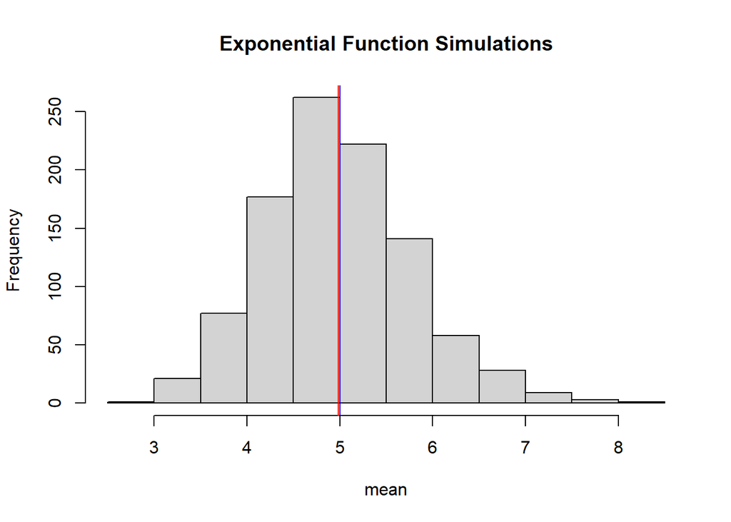

```r
hist(mean_exp, xlab = "mean", main = "Exponential Function Simulations")
abline(v = analytical_mean, col = "red")
abline(v = theoretical_mean, col = "blue")
```

```r
cat("As you see the histogram above, the theoretical mean is", theoretical_mean, ", while the analythical mean is", analytical_mean, ".", "It shows that the center of distribution of averages of 40 exponentials is very close to the theoretical center of the distribution.")
```

```
## As you see the histogram above, the theoretical mean is 5 , while the analythical mean is 4.986508 . It shows that the center of distribution of averages of 40 exponentials is very close to the theoretical center of the distribution.
```

## Question 2

Show how variable the sample is (via variance) and compare it to the theoretical variance of the distribution.

```r
analytical_sd <- sd(mean_exp); analytical_sd
```

```
## [1] 0.7965177
```

```r
theoretical_sd <- (1/lambda)/sqrt(n); theoretical_sd
```

```
## [1] 0.7905694
```

```r
analytical_sd^2
```

```
## [1] 0.6344405
```

```r
theoretical_sd^2
```

```
## [1] 0.625
```

```r
cat("The theorical variance is", theoretical_sd^2, ", and the analytical variance is", analytical_sd^2)
```

```
## The theorical variance is 0.625 , and the analytical variance is 0.6344405
```

## Question 3

Show that the distribution is approximately normal.

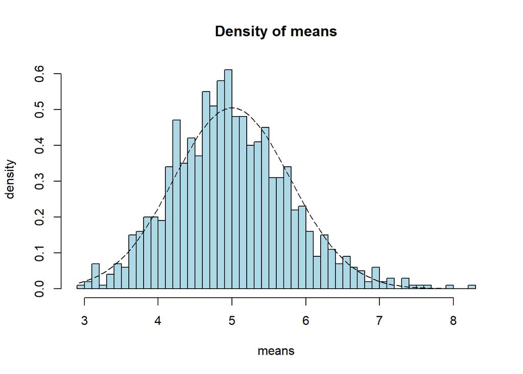

```r
xfit <- seq(min(mean_exp), max(mean_exp), length=100)
yfit <- dnorm(xfit, mean=1/lambda, sd=(1/lambda/sqrt(n)))
hist(mean_exp,breaks=n,prob=T,col="lightblue",xlab = "means",main="Density of means",ylab="density")
lines(xfit, yfit, pch=22, col="black", lty=5)
```

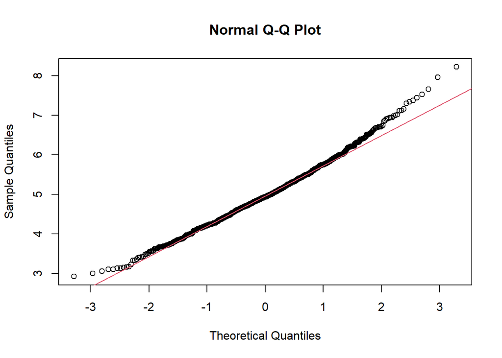

```r
# compare the distribution of averages of 40 exponentials to a normal distribution
qqnorm(mean_exp)
qqline(mean_exp, col = 2)
```

# Part 2

## Instructions

1. Load the ToothGrowth data and perform some basic exploratory data analyses
2. Provide a basic summary of the data.
3. Use confidence intervals and/or hypothesis tests to compare tooth growth by supp and dose. (Only use the techniques from class, even if there’s other approaches worth considering)
4. State your conclusions and the assumptions needed for your conclusions.

## Load “ToothGrowth” dataset

```r
data(ToothGrowth)
```

## Exploartory Data Analysis

```r
dim(ToothGrowth)
```

```
## [1] 60  3
```

```
It shows that the data "ToothGrowth" has 60 rows and 3 columns.
```

```r
str(ToothGrowth)
```

```
## 'data.frame':    60 obs. of  3 variables:
##  $ len : num  4.2 11.5 7.3 5.8 6.4 10 11.2 11.2 5.2 7 ...
##  $ supp: Factor w/ 2 levels "OJ","VC": 2 2 2 2 2 2 2 2 2 2 ...
##  $ dose: num  0.5 0.5 0.5 0.5 0.5 0.5 0.5 0.5 0.5 0.5 ...
```

```
ToothGrowth has three variables: two numeric variables (len & dose) and one factor variable (supp).
```

```r
summary(ToothGrowth)
```

```
##       len        supp         dose
##  Min.   : 4.20   OJ:30   Min.   :0.500
##  1st Qu.:13.07   VC:30   1st Qu.:0.500
##  Median :19.25           Median :1.000
##  Mean   :18.81           Mean   :1.167
##  3rd Qu.:25.27           3rd Qu.:2.000
##  Max.   :33.90           Max.   :2.000
```

## Check levels of the variable “supp”

```r
unique(ToothGrowth$supp)
```

```
## [1] VC OJ
## Levels: OJ VC
```

## Check levels of the variable “dose”

```r
unique(ToothGrowth$dose)
```

```
## [1] 0.5 1.0 2.0
```

## Check missing values

```r
sum(is.na(ToothGrowth))
```

```
## [1] 0
```

## Compare tooth growth by supp

We know that supp has two levels “VC” and “OJ”. Let $H_0: \theta = 0$ and $H_\alpha: \theta \neq 0$, while $\theta$ shows the difference in the means. $\alpha = 0.05$

```r
tg_oj <- ToothGrowth$len[ToothGrowth$supp == "OJ"]
tg_vc <- ToothGrowth$len[ToothGrowth$supp == "VC"]

t.test(tg_oj, tg_vc, alt = "two.sided")
```

```
##
##  Welch Two Sample t-test
##
## data:  tg_oj and tg_vc
## t = 1.9153, df = 55.309, p-value = 0.06063
## alternative hypothesis: true difference in means is not equal to 0
## 95 percent confidence interval:
##  -0.1710156  7.5710156
## sample estimates:
## mean of x mean of y
##  20.66333  16.96333
```

```
The given p-value is 0.06, so we fail to reject the null hypothesis. The 95% CI for the difference in means is approximately (-0.17, 7.57). It also means that we fail to reject the null hypothesis.
```

## Compare tooth growth by dose

```r
tg_05 <- ToothGrowth$len[ToothGrowth$dose == 0.5]
tg_10 <- ToothGrowth$len[ToothGrowth$dose == 1.0]
tg_20 <- ToothGrowth$len[ToothGrowth$dose == 2.0]
```

## Compare tooth growth by dose is 0.5 vs. 1.0

```r
t.test(tg_05, tg_10, alt = "two.sided")
```

```
##
##  Welch Two Sample t-test
##
## data:  tg_05 and tg_10
## t = -6.4766, df = 37.986, p-value = 1.268e-07
## alternative hypothesis: true difference in means is not equal to 0
## 95 percent confidence interval:
##  -11.983781  -6.276219
## sample estimates:
## mean of x mean of y
##    10.605    19.735
```

```
The given p-value is under 0.05, so we reject the null hypothesis. The 95% CI for the difference in means is approximately (-11.9, -6.27). It also means that we reject the null hypothesis.
```

## Compare tooth growth by dose is 1.0 vs. 2.0

```r
t.test(tg_10, tg_20, alt = "two.sided")
```

```
##
##  Welch Two Sample t-test
##
## data:  tg_10 and tg_20
## t = -4.9005, df = 37.101, p-value = 1.906e-05
## alternative hypothesis: true difference in means is not equal to 0
## 95 percent confidence interval:
##  -8.996481 -3.733519
## sample estimates:
## mean of x mean of y
##    19.735    26.100
```

```
The given p-value is under 0.05, so we reject the null hypothesis. The 95% CI for the difference in means is approximately (-8.99, -3.73). It also means that we reject the null hypothesis.
```

## Compare tooth growth by dose is 0.5 vs. 2.0

```r
t.test(tg_05, tg_20, alt = "two.sided")
```

```
##
##  Welch Two Sample t-test
##
## data:  tg_05 and tg_20
## t = -11.799, df = 36.883, p-value = 4.398e-14
## alternative hypothesis: true difference in means is not equal to 0
## 95 percent confidence interval:
##  -18.15617 -12.83383
## sample estimates:
## mean of x mean of y
##    10.605    26.100
```

```
The given p-value is under 0.05, so we reject the null hypothesis. The 95% CI for the difference in means is approximately (-18.1, -12.83). It also means that we reject the null hypothesis.
```